# EDA Part3 - Final Capstone Project

```python
# Updgrade Pandas version
!pip3 install pandas --upgrade
```

```
Keyring is skipped due to an exception: 'keyring.backends'
WARNING: Running pip as the 'root' user can result in broken permissions and conflicting behaviour with the system package manager. It is recommended to use a virtual environment instead: https://pip.pypa.io/warnings/venv
```

```python
# Updgrade Numpy version
!pip3 install numpy --upgrade
```

```
Keyring is skipped due to an exception: 'keyring.backends'
WARNING: Running pip as the 'root' user can result in broken permissions and conflicting behaviour with the system package manager. It is recommended to use a virtual environment instead: https://pip.pypa.io/warnings/venv
```

```python
!pip3 install seaborn --upgrade
```

```
Keyring is skipped due to an exception: 'keyring.backends'
WARNING: Running pip as the 'root' user can result in broken permissions and conflicting behaviour with the system package manager. It is recommended to use a virtual environment instead: https://pip.pypa.io/warnings/venv
```

```python
import pandas as pd
import matplotlib as plt
import seaborn as sns
%matplotlib inline
```

# FINAL CAPSTONE PROJECT OVERVIEW

- In this project, we will perform basic Exploratory Data Analysis (EDA) on the Kyphosis disease Dataset.
- Kyphosis is an abnormally excessive convex curvature of the spine.
- Dataset contains 81 rows and 4 columns representing data on children who have had corrective spinal surgery.
  - INPUTS: 1. Age: in months, 2. Number: the number of vertebrae involved, 3. Start: the number of the first (topmost) vertebra operated on.
  - OUTPUTS: Kyphosis which represents a factor with levels absent present indicating if a kyphosis (a type of deformation) was present after the operation.
- Using the “kyphosis.csv" included in the course package, write a python script to perform the following tasks:
  1. Import the “kyphosis.csv" file using Pandas
  2. Perform basic Exploratory Data Analysis (EDA) on the data
  3. List the average, minimum and maximum age (in years) considered in this study using 2 methods
  4. Plot the correlation matrix
  5. Convert the age column datatype from int64 to float64
  6. Define a function that converts age from months to years
  7. Apply the function to the “Age” column and add the results into a new column entitled “Age in Years”
  8. What are the features of the oldest and youngest child in this study?

```python
# Import the “kyphosis.csv" file using Pandas
kd_df = pd.read_csv('data/kyphosis_disease.csv')
kd_df
```

|  | Kyphosis | Age | Number | Start |
| --- | --- | --- | --- | --- |
| 0 | absent | 71 | 3 | 5 |
| 1 | absent | 158 | 3 | 14 |
| 2 | present | 128 | 4 | 5 |
| 3 | absent | 2 | 5 | 1 |
| 4 | absent | 1 | 4 | 15 |
| ... | ... | ... | ... | ... |
| 76 | present | 157 | 3 | 13 |
| 77 | absent | 26 | 7 | 13 |
| 78 | absent | 120 | 2 | 13 |
| 79 | present | 42 | 7 | 6 |
| 80 | absent | 36 | 4 | 13 |

81 rows × 4 columns

```python
# Perform basic Exploratory Data Analysis (EDA) on the data
kd_df.head(10)
```

|  | Kyphosis | Age | Number | Start |
| --- | --- | --- | --- | --- |
| 0 | absent | 71 | 3 | 5 |
| 1 | absent | 158 | 3 | 14 |
| 2 | present | 128 | 4 | 5 |
| 3 | absent | 2 | 5 | 1 |
| 4 | absent | 1 | 4 | 15 |
| 5 | absent | 1 | 2 | 16 |
| 6 | absent | 61 | 2 | 17 |
| 7 | absent | 37 | 3 | 16 |
| 8 | absent | 113 | 2 | 16 |
| 9 | present | 59 | 6 | 12 |

```python
# List the average, minimum and maximum age (in years) considered in this study using 2 methods - Method 1
kd_df.describe()
```

|  | Age | Number | Start |
| --- | --- | --- | --- |
| count | 81.000000 | 81.000000 | 81.000000 |
| mean | 83.654321 | 4.049383 | 11.493827 |
| std | 58.104251 | 1.619423 | 4.883962 |
| min | 1.000000 | 2.000000 | 1.000000 |
| 25% | 26.000000 | 3.000000 | 9.000000 |
| 50% | 87.000000 | 4.000000 | 13.000000 |
| 75% | 130.000000 | 5.000000 | 16.000000 |
| max | 206.000000 | 10.000000 | 18.000000 |

```python
# List the average, minimum and maximum age (in years) considered in this study using 2 methods - Method 2
age_mean = kd_df['Age'].mean()
age_max = kd_df['Age'].max()
age_min = kd_df['Age'].min()

print(f'avg age: {age_mean}, max age: {age_max}, min age: {age_min}')
```

```
avg age: 83.65432098765432, max age: 206, min age: 1
```

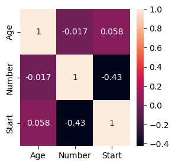

```python
# Plot the correlation matrix

import matplotlib.pyplot as plt
import seaborn as sns
correlations = kd_df.corr()
f, ax = plt.subplots(figsize = (3, 3))
sns.heatmap(correlations, annot = True)
```

```python
# Convert the age column datatype from int64 to float64
kd_df["Age"] = kd_df['Age'].astype("float64")
kd_df.info()
```

```
<class 'pandas.core.frame.DataFrame'>
RangeIndex: 81 entries, 0 to 80
Data columns (total 4 columns):
 #   Column    Non-Null Count  Dtype
---  ------    --------------  -----
 0   Kyphosis  81 non-null     object
 1   Age       81 non-null     float64
 2   Number    81 non-null     int64
 3   Start     81 non-null     int64
dtypes: float64(1), int64(2), object(1)
memory usage: 2.7+ KB
```

```python
# Define a function that converts age from months to years
def months_to_years(months):
    return (months/12)
```

```python
# Apply the function to the “Age” column and add the results into a new column entitled “Age in Years”
kd_df["Age in Years"] = kd_df["Age"].apply(months_to_years)
kd_df
```

|  | Kyphosis | Age | Number | Start | Age in Years |
| --- | --- | --- | --- | --- | --- |
| 0 | absent | 71.0 | 3 | 5 | 5.916667 |
| 1 | absent | 158.0 | 3 | 14 | 13.166667 |
| 2 | present | 128.0 | 4 | 5 | 10.666667 |
| 3 | absent | 2.0 | 5 | 1 | 0.166667 |
| 4 | absent | 1.0 | 4 | 15 | 0.083333 |
| ... | ... | ... | ... | ... | ... |
| 76 | present | 157.0 | 3 | 13 | 13.083333 |
| 77 | absent | 26.0 | 7 | 13 | 2.166667 |
| 78 | absent | 120.0 | 2 | 13 | 10.000000 |
| 79 | present | 42.0 | 7 | 6 | 3.500000 |
| 80 | absent | 36.0 | 4 | 13 | 3.000000 |

81 rows × 5 columns

```python
# What are the features of the oldest in the study?
kd_df[ (kd_df['Age']==kd_df["Age"].max()) ]
```

|  | Kyphosis | Age | Number | Start | Age in Years |
| --- | --- | --- | --- | --- | --- |
| 73 | absent | 206.0 | 4 | 10 | 17.166667 |

```python
# What are the features of the youngest in this study?
kd_df[ (kd_df['Age']==kd_df["Age"].min()) ]
```

|  | Kyphosis | Age | Number | Start | Age in Years |
| --- | --- | --- | --- | --- | --- |
| 4 | absent | 1.0 | 4 | 15 | 0.083333 |
| 5 | absent | 1.0 | 2 | 16 | 0.083333 |
| 13 | absent | 1.0 | 4 | 12 | 0.083333 |
| 15 | absent | 1.0 | 3 | 16 | 0.083333 |
| 36 | absent | 1.0 | 3 | 9 | 0.083333 |